# MDI 343 TP2 k-plus proches voisins, analyse discriminante linéaire et régression logistique

#### Importation des données

```python
# Importation du fichier source du TP KNN
import tp_knn_source as source_TP2


import numpy as np
import pandas as pd
import matplotlib.pyplot as plt
from matplotlib import cm
from sklearn import neighbors, model_selection
import seaborn as sns
from matplotlib.colors import ListedColormap

from sklearn.preprocessing import StandardScaler
from collections import Counter
from sklearn.metrics.pairwise import euclidean_distances

from sklearn.neighbors import KNeighborsClassifier

from sklearn.datasets import load_digits

from sklearn.base import BaseEstimator, ClassifierMixin

from sklearn import linear_model

from sklearn.discriminant_analysis import LinearDiscriminantAnalysis
```

## Génération de données artificielles

### Fonctions de génération artificielles de données

### Question 1

Étudiez les fonctions rand_bi_gauss, rand_tri_gauss, rand_clown et rand_checkers.

- Que renvoient ces fonctions ?
- À quoi correspond la dernière colonne ?
- Générez les données en utilisant chaque de ces 4 fonctions avec les valeurs des paramètres suivantes :

##### rand_bi_gauss pour :

- 20 observations pour classe centrée $(1,1)^{T}, (-1,-1)^{T}$
- Ecart type 0.9 pour chaque classe

```python
X_1_data_rand_bi_gauss, Y_1_data_rand_bi_gauss = source_TP2.rand_bi_gauss(n1=20, n2=20, mu1=[1, 1], mu2=[-1, -1], sigmas1=[0.9, 0.9],
                  sigmas2=[0.9, 0.9])
print("X = ", X_1_data_rand_bi_gauss)
print("\n\n")
print("Y = ", Y_1_data_rand_bi_gauss)
```

```
X =  [[-0.30623403 -2.08301931]
 [ 0.40388646 -1.43390556]
 [ 2.17610388  1.22277462]
 [ 1.12414472  1.88772753]
 [ 1.01192165  1.22090772]
 [ 0.98491893  1.7677381 ]
 [-0.42020355 -1.83651975]
 [ 0.62198885 -1.0524158 ]
 [ 0.46681367  1.45492482]
 [-2.46664948 -0.64193661]
 [ 0.74063788  0.98067103]
 [-1.30165382  0.14713445]
 [ 2.0573283   0.66752374]
 [ 1.16819904 -0.49102898]
 [ 0.7634533  -0.45454782]
 [-0.95851384  0.66051459]
 [-0.87688112 -0.89671728]
 [-1.4304139  -1.42614141]
 [-1.326186   -0.73586726]
 [-0.53218988 -0.44659469]
 [ 0.89497805  1.98900338]
 [-0.67163179 -2.22394772]
 [-1.17450104 -0.8808393 ]
 [-0.82525295  1.83040664]
 [-1.66168697 -0.79674833]
 [ 1.27069375  1.26018198]
 [-1.77969249  0.76071995]
 [-0.35652735  1.71683816]
 [-1.17543185 -1.4580517 ]
 [ 0.09488732  0.13591983]
 [ 0.41795906  1.35987413]
 [ 0.977552    1.89480224]
 [-0.93931701  0.96185148]
 [-2.12233019 -1.53291869]
 [ 2.13792498 -0.7829728 ]
 [-0.72741661 -2.15184964]
 [ 2.33901675 -0.36579599]
 [ 0.49678968 -1.61255421]
 [ 2.0868508   0.60804132]
 [-0.93984109  0.40213695]]



Y =  [-1. -1.  1.  1.  1.  1. -1. -1.  1. -1.  1. -1.  1.  1.  1.  1. -1. -1.
 -1. -1.  1. -1. -1.  1. -1.  1. -1.  1. -1.  1.  1.  1. -1. -1.  1. -1.
  1. -1.  1. -1.]
```

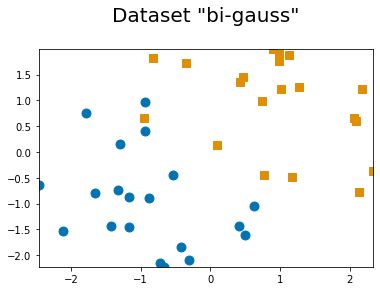

```python
source_TP2.plot_2d(X_1_data_rand_bi_gauss, Y_1_data_rand_bi_gauss)
plt.title('Dataset "bi-gauss"\n', size=20)
```

#### Réponse :

La fonction **rand_bi_gauss** retourne des points d'observations (data points) généré aléatoirement suivant 2 lois gaussiennes de paramètres (mu1, sigma1) pour la première loi et (mu2,sigma2) pour la seconde loi. Enfin la fonction retourne les labels associés à chaque observation qui sont -1 ou 1.

##### rand_tri_gauss pour :

- chaque classe centrée $(1,1)^{T}, (-1,-1)^{T} et (1,-1)^{T}$
- Ecart type 0.9 pour chaque classe

```python
X_2_data_rand_tri_gauss, Y_2_data_rand_tri_gauss = source_TP2.rand_tri_gauss(n1=50, n2=50, n3=50, mu1=[1, 1],
                   mu2=[-1, -1], mu3=[1, -1], sigma1=[0.9, 0.9],
                   sigma2=[0.9, 0.9], sigma3=[0.9, 0.9])
print(X_2_data_rand_tri_gauss)
print("\n\n")
print(Y_2_data_rand_tri_gauss)
```

```
[[ 0.93090773  0.09383795]
 [ 0.60590304 -0.7943994 ]
 [ 1.03488273  0.46411796]
 [-1.17048749 -0.96186568]
 [-1.24235678 -1.74438953]
 [-1.76726376 -1.83480226]
 [-2.2129798  -0.07984628]
 [-1.07938203 -1.35998015]
 [-0.63938196 -0.15581099]
 [-1.44121701 -2.78301049]
 [ 0.51333762 -1.14413912]
 [ 0.68819773 -1.38825139]
 [-0.54883151  0.48559953]
 [-0.99029472 -2.07327519]
 [-0.58709392 -0.09080905]
 [-1.29072586 -2.73270947]
 [ 1.64751059  0.24555681]
 [-0.27107818 -0.65490712]
 [ 1.04168906 -1.00208909]
 [ 1.65655013  1.60226425]
 [ 0.73553067 -2.04990165]
 [ 1.26018135  1.25319365]
 [ 0.60915491 -1.20969584]
 [-0.96944129 -0.38253928]
 [ 2.11304098  2.23619407]
 [ 0.89776705 -1.14244034]
 [ 1.3119807  -0.75421795]
 [-0.3723414  -2.95304106]
 [ 0.83520128  1.40601707]
 [-1.63314979 -0.7413633 ]
 [-0.09934168 -0.55475769]
 [ 1.18178576 -0.99780194]
 [ 0.297064    1.7840116 ]
 [-2.64007462 -2.30548   ]
 [-1.96470654 -1.05448029]
 [ 1.33499003  0.67140795]
 [-2.58435584 -1.09919481]
 [-0.72143787 -2.56673747]
 [ 1.06504743 -0.23846746]
 [-0.72981084 -0.47310212]
```

[output cut: 105 more lines]

```
 [ 1.63710212  0.79510343]
 [ 2.05477985  0.30218571]
 [ 1.46435822 -0.12097496]
 [ 0.78458441 -0.64640919]
 [ 1.50948853  2.1405153 ]]



[1. 3. 1. 2. 2. 2. 2. 2. 2. 2. 3. 3. 1. 2. 2. 2. 1. 3. 3. 1. 3. 1. 3. 2.
 1. 3. 3. 3. 1. 2. 3. 3. 1. 2. 2. 1. 2. 3. 3. 2. 2. 3. 2. 3. 3. 2. 3. 2.
 1. 3. 1. 3. 1. 3. 2. 3. 3. 2. 1. 2. 2. 1. 3. 1. 2. 3. 3. 1. 3. 1. 1. 2.
 2. 1. 2. 2. 1. 3. 2. 3. 2. 1. 3. 1. 3. 3. 2. 2. 1. 2. 1. 1. 1. 1. 1. 2.
 2. 3. 1. 1. 1. 2. 1. 2. 3. 1. 3. 3. 2. 1. 2. 2. 2. 1. 3. 1. 2. 2. 3. 3.
 3. 3. 1. 1. 1. 2. 3. 1. 1. 1. 1. 3. 3. 1. 2. 2. 2. 3. 3. 2. 1. 3. 3. 3.
 2. 1. 1. 1. 3. 1.]
```

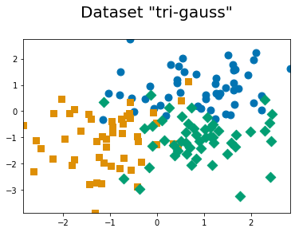

```python
source_TP2.plot_2d(X_2_data_rand_tri_gauss, Y_2_data_rand_tri_gauss)
plt.title('Dataset "tri-gauss"\n', size=20)
```

#### Réponse :

La fonction **rand_tri_gauss** retourne des points d'observations (data points) générés aléatoirement suivant 3 lois gaussiennes de paramètres (mu1, sigma1) pour la première loi, (mu2,sigma2) pour la seconde loi et (mu3,sigma3) pour la troisème loi. Enfin la fonction retourne les labels associés à chaque observation qui sont 1, 2 ou 3.

##### rand_clown pour :

```python
X_3_data_rand_clown, Y_3_data_rand_clown = source_TP2.rand_clown(n1=150, n2=150, sigma1=1, sigma2=2)

print(X_3_data_rand_clown)
print("\n\n")
print(Y_3_data_rand_clown)
```

```
[[-2.99529385e+00  2.80900094e+00]
 [-7.42798489e-01  2.36825779e+00]
 [ 6.19096347e-01  5.76752914e-01]
 [ 7.62601064e-01 -8.45216517e-01]
 [ 1.06933913e+00  4.42355015e-01]
 [-1.83131979e+00  1.55428408e+00]
 [-7.29158690e-01  1.14069312e+00]
 [ 9.96731620e-01 -8.12808823e-02]
 [ 2.10437753e+00  2.60808013e+00]
 [-6.91701157e+00 -2.27903404e+00]
 [ 1.20560611e+00  2.59213351e+00]
 [ 1.76501606e+00  3.43229048e+00]
 [-1.79633438e+00  3.64835708e+00]
 [-6.77669541e-01  1.00873023e+00]
 [ 2.82286512e+00  7.30879497e+00]
 [-2.08383621e-01  1.85482532e+00]
 [-2.40230688e-01  5.97358127e+00]
 [ 1.13208551e+00  1.05973849e-01]
 [-5.11873814e-01 -1.34702020e+00]
 [ 3.63931744e+00  1.50597678e+00]
 [-6.15495713e-01 -5.83479318e-01]
 [ 6.51125476e-01  2.70061710e-01]
 [-1.35072722e+00  3.26992453e+00]
 [ 8.94759506e-01  3.23883450e+00]
 [ 1.67138250e+00 -2.46396123e+00]
 [ 2.93556328e-01 -5.07213441e-01]
 [-1.59545787e+00  4.86025162e+00]
 [ 2.15344858e+00  1.82871244e-01]
 [-2.58737389e+00  4.26903501e+00]
 [ 1.60371199e+00  3.96272437e+00]
 [-1.90314349e+00  2.84398068e+00]
 [ 2.87142941e+00  3.88365865e+00]
 [ 1.02923429e+00 -8.33454852e-01]
 [-1.12497111e+00 -6.11072691e-01]
 [ 2.86078447e+00  9.80611957e-01]
 [ 3.12872546e+00 -3.77449886e-01]
 [-5.91764725e-02  1.86164753e+00]
 [ 1.22678397e+00  2.31826012e+00]
 [ 2.20253880e+00  4.82752899e+00]
 [ 2.05747050e+00  3.51919309e+00]
```

[output cut: 265 more lines]

```
 -1. -1.  1.  1.  1.  1. -1.  1.  1. -1. -1.  1. -1.  1. -1. -1.  1.  1.
  1. -1.  1. -1. -1. -1. -1. -1. -1.  1. -1. -1. -1.  1. -1. -1.  1.  1.
 -1.  1. -1. -1.  1. -1.  1.  1. -1.  1. -1.  1. -1. -1. -1. -1. -1. -1.
  1.  1.  1. -1. -1. -1. -1. -1. -1. -1. -1. -1. -1. -1. -1. -1.  1.  1.
  1. -1.  1.  1. -1. -1. -1. -1. -1.  1.  1.  1.  1. -1.  1.  1. -1.  1.
  1.  1.  1.  1.  1.  1.  1.  1.  1. -1. -1.  1.  1. -1.  1. -1.  1. -1.
  1.  1. -1. -1. -1. -1.  1. -1.  1. -1. -1. -1. -1.  1. -1.  1. -1.  1.
 -1.  1. -1.  1. -1. -1.  1. -1.  1.  1. -1.  1.  1. -1.  1. -1. -1.  1.
 -1. -1.  1. -1. -1.  1. -1.  1.  1.  1. -1.  1.  1.  1.  1.  1. -1. -1.
  1. -1.  1.  1. -1.  1. -1. -1.  1. -1.  1. -1. -1.  1. -1. -1.  1. -1.
  1. -1. -1. -1.  1.  1.  1. -1. -1. -1.  1. -1.  1. -1.  1.  1. -1. -1.
 -1. -1.  1. -1.  1.  1. -1.  1. -1.  1.  1.  1.  1.  1.  1.  1. -1. -1.
  1. -1.  1.  1. -1. -1.  1. -1.  1.  1.  1. -1. -1. -1.  1.  1. -1.  1.
 -1. -1.  1. -1.  1.  1.  1. -1.  1.  1. -1.  1. -1.  1.  1. -1.  1. -1.
  1. -1.  1.  1. -1.  1. -1.  1. -1. -1.  1.  1.]
```

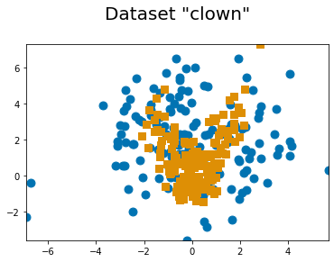

```python
source_TP2.plot_2d(X_3_data_rand_clown, Y_3_data_rand_clown)
plt.title('Dataset "clown"\n', size=20)
```

#### Réponse :

La fonction **rand_clown** retourne des points d'observations (data points) générés aléatoirement avec du bruit et d'écart-type sigma1 pour la première classe et sigma2 pour la seconde classe Enfin la fonction retourne les labels associés à chaque observation qui sont -1 ou 1.

##### rand_checkers pour :

- Valeur 150 pour le premier et le deuxième argument
- On laisse le troisième argument par défaut

```python
X_4_data_rand_checker, Y_4_data_rand_checker = source_TP2.rand_checkers(n1=150, n2=150, sigma=0.1)

print(X_4_data_rand_checker)
print("\n\n")
print(Y_4_data_rand_checker)
```

```
[[-0.69587183  0.06222493]
 [-0.14798801  0.42096131]
 [-0.60543934 -1.22596018]
 [ 0.02476669 -0.22209577]
 [ 1.86995114  1.25965137]
 [ 0.24961796 -1.40771436]
 [ 0.33393379  1.00901868]
 [ 1.62541571 -0.69642445]
 [-0.58516648  0.84455242]
 [-0.97833026 -1.13861636]
 [-0.14865832 -1.49383948]
 [-0.75154875  0.73193773]
 [-0.89745327 -1.73473406]
 [ 0.30504302  0.39092425]
 [ 1.39295714  0.31968835]
 [ 0.98928465  0.55221536]
 [ 0.83591034 -1.00331756]
 [-1.9309683  -1.45711076]
 [-1.67336514  0.79901915]
 [-0.41368884  0.85969699]
 [ 1.12567139 -0.53915964]
 [ 1.53089877 -0.71530296]
 [-1.93598644  0.32649199]
 [ 1.9271554   0.79973084]
 [ 0.93145479 -1.65433387]
 [ 1.79730707  1.40536502]
 [-1.17558179 -1.31809941]
 [ 0.21668303 -1.49662651]
 [-1.37694106 -0.29109306]
 [-0.15422125  0.92193557]
 [ 0.21771828  0.11499021]
 [-1.3685287  -1.24228776]
 [-0.9140449  -0.53906505]
 [ 0.83148122  0.72081146]
 [ 1.08709619 -2.02850808]
 [-0.94235109 -0.53535205]
 [-1.48462577  1.90791339]
 [-1.93633212  0.42848992]
 [ 0.19241677 -0.45582776]
 [ 1.69031453 -0.06887405]
```

[output cut: 248 more lines]

```



[1. 3. 1. 3. 1. 1. 2. 1. 3. 1. 1. 3. 1. 1. 2. 1. 3. 1. 1. 3. 1. 1. 1. 2.
 1. 1. 1. 1. 1. 3. 3. 1. 1. 1. 1. 1. 3. 1. 3. 2. 1. 3. 3. 1. 1. 1. 3. 1.
 1. 1. 2. 2. 3. 3. 1. 1. 3. 2. 1. 1. 1. 1. 1. 2. 1. 3. 1. 1. 1. 1. 1. 2.
 1. 1. 1. 2. 1. 1. 1. 3. 1. 2. 1. 1. 1. 3. 2. 2. 1. 3. 1. 3. 2. 1. 1. 2.
 2. 2. 1. 3. 3. 1. 1. 1. 1. 1. 1. 3. 3. 1. 1. 3. 1. 1. 2. 1. 2. 1. 1. 1.
 3. 1. 3. 1. 1. 1. 1. 1. 1. 1. 2. 3. 2. 1. 1. 3. 2. 1. 1. 1. 1. 1. 1. 1.
 1. 1. 3. 2. 1. 3. 3. 2. 1. 3. 1. 3. 1. 1. 1. 2. 1. 3. 3. 2. 1. 1. 1. 1.
 1. 1. 1. 1. 1. 1. 3. 1. 3. 1. 3. 1. 1. 1. 1. 1. 1. 1. 1. 2. 1. 2. 3. 3.
 1. 1. 1. 3. 1. 1. 1. 2. 1. 3. 1. 3. 3. 1. 1. 1. 1. 1. 1. 3. 2. 1. 1. 1.
 1. 1. 2. 3. 2. 1. 3. 1. 3. 3. 1. 3. 2. 1. 1. 1. 1. 3. 1. 3. 1. 3. 1. 1.
 3. 3. 1. 3. 2. 3. 2. 1. 2. 3. 1. 1. 1. 1. 1. 1. 1. 3. 1. 1. 3. 1. 3. 1.
 1. 1. 3. 1. 3. 1. 1. 3. 1. 3. 3. 1. 1. 1. 3. 1. 1. 1. 3. 1. 1. 1. 3. 3.]
```

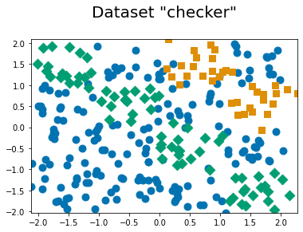

```python
source_TP2.plot_2d(X_4_data_rand_checker, Y_4_data_rand_checker)
plt.title('Dataset "checker"\n', size=20)
```

#### Réponse :

La fonction **rand_checker** retourne des points d'observations (data points) générés aléatoirement avec du bruit et d'écart-type sigma 0.1 Enfin la fonction retourne les labels associés à chaque observation qui sont 1, 2 ou 3.

### K-Plus proches voisins (K-NN)

#### Question 3 :

#### Réponse

L'objectif de la méthode K-NN est de prédire la classe d'un point selon la classe majoritaire de ses $K$ plus proche voisins.

Pour l'approche intuitive (i.e régression) l'idée est de calculer la moyenne des labels du point courant (point dont il faut prédire la classe) et tout ses $K$ plus proche voisins.

Pour ce faire la classe prédite du point courant peut être calculée avec la formule suivante : $\hat{y}=\frac{1}{k} \sum_{i=1}^{n} y_{i}$ la moyenne  
avec :

- l'indice k étant le nombre des plus proches voisins du point x.

Ainsi, on fait la moyenne sur tous les $y_{i}$ (les labels des plus proches voisins de x)

Une autre version adapté pourra être de sélectionner l'ensemble des points les plus proche de l'hyperplan de manière tout en faisant attention à ce que la distance euclidienne soit la plus minimale possible. En effet, le but de la regression est trouver les coefficients qui minimisent la distance ce qui revient à miniser la norme euclidienne.

#### Question 4 :

#### Les étapes de l'implémentation

**Etape 1** : On calcul la distance entre le point dont il faut prédire la classe et tous les points du dataset. On stocke ces valeurs de distance dans un tableau

**Etape_2** : On ordonne ce tableau dans l'ordre croissant (plus petite distance à la plus grande distance)

**Etape_3** : On garde les **K** plus petite distance. **K** est paramètre intialisé au début de l'algorithme (choisi par l'utilisateur)

**Etape_4** : On regarde la classe des points qui ont les **K** plus petite distance.

**Etape_5** : La classe majoritaire devient la classe du point à prédire. (vote de la majorité)

### Algorithme KNN from scratch

#### Construction du dataset

- Index pair pour le jeu d'entrainement
- Index impair pour le jeu de test

```python
def build_dataset(X, y):
    # On formate X en dataframe
    df_X = pd.DataFrame(X)
    # print(df_X)

    # On sélectionne les valeurs dont les indices sont pair uniquement
    X_pair = df_X.iloc[::2]
    # print(X_pair)

    # Construction du jeu d'entrainement X_train
    X_train = X_pair
    y_train = pd.Series(y).iloc[::2]
    # print(X_train)
    # print(y_train)

    # On sélectionne les valeurs dont les indices sont impairs
    indice_impair = [i+1 for i in list(X_pair.index.values)]
    X_impair = df_X.iloc[indice_impair]

    # Construction du jeu de test
    X_test = X_impair
    y_test = pd.Series(y).iloc[indice_impair]
    print(X_test)
    print(y_test)

    # On met sur la même echelle les valeurs pour ne pas fausser le calcul des distances
    scaler = StandardScaler()
    X_train = scaler.fit_transform(X_train)
    X_test = scaler.transform(X_test)

    print("\n\n-------------- X_train --------------\n\n")
    print(X_train)
    print("\n\n-------------- y_train --------------\n\n")
    print(y_train)
    print("\n\n-------------- X_test --------------\n\n")
    print(X_test)
    print("\n\n-------------- y_test --------------\n\n")
    print(y_test)

    return X_train, y_train, X_test, y_test
```

#### On visualise $X_{train}, X_{test}, y_{train}, y_{test}$

```python
X_train, y_train, X_test, y_test = build_dataset(X_2_data_rand_tri_gauss, Y_2_data_rand_tri_gauss)
```

```
            0         1
1    0.605903 -0.794399
3   -1.170487 -0.961866
5   -1.767264 -1.834802
7   -1.079382 -1.359980
9   -1.441217 -2.783010
..        ...       ...
141  0.375014 -1.686443
143  1.984687 -0.774106
145  1.637102  0.795103
147  1.464358 -0.120975
149  1.509489  2.140515

[75 rows x 2 columns]
1      3.0
3      2.0
5      2.0
7      2.0
9      2.0
      ...
141    3.0
143    3.0
145    1.0
147    1.0
149    1.0
Length: 75, dtype: float64


-------------- X_train --------------


[[ 0.50642843  0.3244072 ]
 [ 0.59011295  0.64053854]
 [-1.24272853 -1.24500322]
 [-2.02393672  0.17612205]
 [-0.75742286  0.1112662 ]
 [ 0.17034616 -0.73253169]
 [-0.68454312  0.6588787 ]
 [-0.71533871  0.16676245]
 [ 1.0831879   0.45393914]
```

[output cut: 165 more lines]

```
-------------- y_test --------------


1      3.0
3      2.0
5      2.0
7      2.0
9      2.0
      ...
141    3.0
143    3.0
145    1.0
147    1.0
149    1.0
Length: 75, dtype: float64
```

```python
def KNNClassifier(X_train, X_test, y_train, y_test, k_voisin):
    # Faisons une prédiction sur notre dataset
    classe_pred = []

    for test_value in X_test:

        # Etape 1 : Calcul des distances euclidiennes

        distances_euc = []
        for train_value in X_train:
            dist = np.sqrt(np.sum(np.square(train_value-test_value)))
            distances_euc.append(dist)

        # On stock les distances dans un dataframe avec comme index correspond l'index du jeu d'entrainement
        df_dists = pd.DataFrame(data=distances_euc, columns=['dist'], index = y_train.index)

        # Etape 2 et 3 : On tri les valeurs des distances pas ordre coirssant et on ne garde uniquement les K-distances les plus petites
        df_nn = df_dists.sort_values(by=['dist'], axis=0)[:k_voisin]

        # Etape 4 : On crée un compteur pour compter l'occurence des labels des k-voisins les plus proches
        class_counter = Counter(y_train[df_nn.index])

        # Etape 5 : Vote majoritaire (On garde uniquement la classe la plus représentée c'est à dire la classe majoritaire)

        sorted_classes = sorted(class_counter.items(), key = lambda x: x[1], reverse = True)
        classe_majoritaire = sorted_classes[0][0]
        #print(classe_majoritaire)

        classe_pred.append(classe_majoritaire)
        #print(classe_pred)

    return classe_pred
```

#### On visualise les classes prédites par notre modèle KNN from scratch

```python
classe_predite = KNNClassifier(X_train, X_test, y_train, y_test, k_voisin=3)
print(classe_predite)
```

```
[3.0, 2.0, 2.0, 2.0, 2.0, 3.0, 2.0, 2.0, 3.0, 1.0, 1.0, 2.0, 3.0, 2.0, 2.0, 3.0, 2.0, 1.0, 2.0, 2.0, 1.0, 3.0, 2.0, 2.0, 3.0, 3.0, 2.0, 1.0, 2.0, 2.0, 3.0, 1.0, 3.0, 1.0, 1.0, 2.0, 1.0, 2.0, 3.0, 2.0, 1.0, 1.0, 3.0, 3.0, 2.0, 3.0, 1.0, 2.0, 1.0, 1.0, 2.0, 2.0, 3.0, 3.0, 3.0, 2.0, 1.0, 1.0, 2.0, 3.0,…
```

#### On visualise les classes prédites par l'agorithme KNN de la librairie scikit-learn

```python
model = KNeighborsClassifier(n_neighbors=3, metric = 'euclidean')
model.fit(X_train,y_train)
predicted = model.predict(X_test)
print(predicted)
```

```
[3. 2. 2. 2. 2. 3. 2. 2. 3. 1. 1. 2. 3. 2. 2. 3. 2. 1. 2. 2. 1. 3. 2. 2.
 3. 3. 2. 1. 2. 2. 3. 1. 3. 1. 1. 2. 1. 2. 3. 2. 1. 1. 3. 3. 2. 3. 1. 2.
 1. 1. 2. 2. 3. 3. 3. 2. 1. 1. 2. 3. 3. 1. 3. 1. 2. 3. 1. 2. 2. 3. 2. 3.
 1. 1. 1.]
```

#### On compare les classe prédites entre le KNN from scratch et le KNN de scikit-learn

```python
def compare_kkn(X_pred_Knn_homemade, X_pred_Knn_Scikit_Learn):
    counter = 0
    for i in range(len(X_pred_Knn_homemade)):
        if X_pred_Knn_homemade[i] == X_pred_Knn_Scikit_Learn.tolist()[i]:
            counter = counter + 1
    print(str(counter) + " classes identiques prédites sur " + str(len(X_pred_Knn_homemade)))

compare_kkn(classe_predite, predicted)
```

```
75 classes identiques prédites sur 75
```

#### On calcule le socre de prédiction des 2 versions du KNN

```python
def score(X_pred, y):
    counter = 0
    for i in range(len(X_pred)):
        if X_pred[i] == y.tolist()[i]:
            counter = counter + 1
    return (counter*100)/len(X_pred)

score_knn_homemade = score(classe_predite, y_test)
print("Le score obtenu par la version from scratch du modèle KNN fait maison est de : " + str(score_knn_homemade) + " %")

score_knn_scikit_learn = score(predicted, y_test)
print("Le score obtenu par le modèle KNN de scikit learn est de : " + str(score_knn_scikit_learn) + " %")
```

```
Le score obtenu par la version from scratch du modèle KNN fait maison est de : 77.33333333333333 %
Le score obtenu par le modèle KNN de scikit learn est de : 77.33333333333333 %
```

#### Question 5 :

Faites tourner sur les quatre exemples de jeu de données cet algorithme de classification, en utilisant la distance euclidienne classique $d(x, v) = |x-v|_2$ et $k = 5$. Visualisez les règles de classification obtenues en utilisant la fonction frontiere_new. (Souvent, les autres choix de distance peuvent être utiles, par exemple la distance de Mahalanobis.)

```python
##############################################
# fonction du tp knn_lda_logreg
##############################################
symlist = ['o', 's', 'D', 'x', '+', '*', 'p', 'v', '-', '^']

def frontiere_new2(clf, X, y, w=None, step=50, alpha_choice=1, colorbar=True,
                  samples=True, n_labels=3, n_neighbors=3, distance = "euclidienne"):
    """Trace la frontiere pour la fonction de decision de clf."""
    min_tot0 = np.min(X[:, 0])
    min_tot1 = np.min(X[:, 1])

    max_tot0 = np.max(X[:, 0])
    max_tot1 = np.max(X[:, 1])
    delta0 = (max_tot0 - min_tot0)
    delta1 = (max_tot1 - min_tot1)
    xx, yy = np.meshgrid(np.arange(min_tot0, max_tot0, delta0 / step),
                         np.arange(min_tot1, max_tot1, delta1 / step))
    XX = np.c_[xx.ravel(), yy.ravel()]
    print(XX.shape)
    z = clf.predict(XX)
    z = z.reshape(xx.shape)
    labels = np.unique(z)
    color_blind_list = sns.color_palette("colorblind", labels.shape[0])
    my_cmap = ListedColormap(color_blind_list)
    plt.imshow(z, origin='lower', interpolation="mitchell", alpha=0.80,
               cmap=my_cmap, extent=[min_tot0, max_tot0, min_tot1, max_tot1])
    if colorbar is True:
        ax = plt.gca()
        cbar = plt.colorbar(ticks=labels)
        cbar.ax.set_yticklabels(labels)

    # color_blind_list = sns.color_palette("colorblind", labels.shape[0])
    # sns.set_palette(color_blind_list)
    ax = plt.gca()
    if samples is True:
        for i, label in enumerate(y):
            label_num = np.where(labels == label)[0][0]
            plt.scatter(X[i, 0], X[i, 1], c=[color_blind_list[label_num]],
                        s=80, marker=symlist[label_num])
    plt.xlim([min_tot0, max_tot0])
    plt.ylim([min_tot1, max_tot1])
    ax.get_yaxis().set_ticks([])
    ax.get_xaxis().set_ticks([])
    if w is not None:
        plt.plot([min_tot0, max_tot0],
                 [min_tot0 * -w[1] / w[2] - w[0] / w[2],
                  max_tot0 * -w[1] / w[2] - w[0] / w[2]],
                 "k", alpha=alpha_choice)
    plt.title("Impact du paramètre k_voisin sur les frontières de classification \n L=" + str(n_labels) + ",k_voisin=" +
              str(n_neighbors) + " \n distance = " +distance)
```

#### On execute sur les 4 jeux de données l'algorithme classifieur KNN avec les paramètres suivants :

- Distance euclidienne
- Nb_voisin = 5

#### Dataset 1# : Rand_Bi_Gauss

```
           0         1
1   0.403886 -1.433906
3   1.124145  1.887728
5   0.984919  1.767738
7   0.621989 -1.052416
9  -2.466649 -0.641937
11 -1.301654  0.147134
13  1.168199 -0.491029
15 -0.958514  0.660515
17 -1.430414 -1.426141
19 -0.532190 -0.446595
21 -0.671632 -2.223948
23 -0.825253  1.830407
25  1.270694  1.260182
27 -0.356527  1.716838
29  0.094887  0.135920
31  0.977552  1.894802
33 -2.122330 -1.532919
35 -0.727417 -2.151850
37  0.496790 -1.612554
39 -0.939841  0.402137
1    -1.0
3     1.0
5     1.0
7    -1.0
9    -1.0
11   -1.0
13    1.0
15    1.0
17   -1.0
19   -1.0
21   -1.0
23    1.0
25    1.0
27    1.0
29    1.0
31    1.0
33   -1.0
35   -1.0
37   -1.0
```

[output cut: 90 more lines]

```
15    1.0
17   -1.0
19   -1.0
21   -1.0
23    1.0
25    1.0
27    1.0
29    1.0
31    1.0
33   -1.0
35   -1.0
37   -1.0
39   -1.0
dtype: float64
(2500, 2)
```

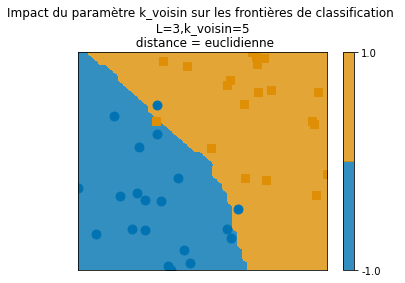

```python
X_train, y_train, X_test, y_test = build_dataset(X_1_data_rand_bi_gauss, Y_1_data_rand_bi_gauss)

knn_clf = KNeighborsClassifier(n_neighbors=5, metric = 'euclidean')
knn_clf = knn_clf.fit(X_train, y_train)
frontiere_new2(knn_clf, X_1_data_rand_bi_gauss, Y_1_data_rand_bi_gauss, n_neighbors=5)
```

#### Dataset 2# : Rand_Tri_Gauss

```
            0         1
1    0.605903 -0.794399
3   -1.170487 -0.961866
5   -1.767264 -1.834802
7   -1.079382 -1.359980
9   -1.441217 -2.783010
..        ...       ...
141  0.375014 -1.686443
143  1.984687 -0.774106
145  1.637102  0.795103
147  1.464358 -0.120975
149  1.509489  2.140515

[75 rows x 2 columns]
1      3.0
3      2.0
5      2.0
7      2.0
9      2.0
      ...
141    3.0
143    3.0
145    1.0
147    1.0
149    1.0
Length: 75, dtype: float64


-------------- X_train --------------


[[ 0.50642843  0.3244072 ]
 [ 0.59011295  0.64053854]
 [-1.24272853 -1.24500322]
 [-2.02393672  0.17612205]
 [-0.75742286  0.1112662 ]
 [ 0.17034616 -0.73253169]
 [-0.68454312  0.6588787 ]
 [-0.71533871  0.16676245]
 [ 1.0831879   0.45393914]
```

[output cut: 166 more lines]

```


1      3.0
3      2.0
5      2.0
7      2.0
9      2.0
      ...
141    3.0
143    3.0
145    1.0
147    1.0
149    1.0
Length: 75, dtype: float64
(2500, 2)
```

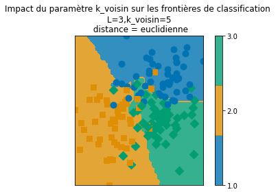

```python
X_train, y_train, X_test, y_test = build_dataset(X_2_data_rand_tri_gauss, Y_2_data_rand_tri_gauss)

knn_clf = KNeighborsClassifier(n_neighbors=5, metric = 'euclidean')
knn_clf = knn_clf.fit(X_train, y_train)
frontiere_new2(knn_clf, X_2_data_rand_tri_gauss, Y_2_data_rand_tri_gauss, n_neighbors=5)
```

#### Dataset 3# : Rand_Clown

```
            0         1
1   -0.742798  2.368258
3    0.762601 -0.845217
5   -1.831320  1.554284
7    0.996732 -0.081281
9   -6.917012 -2.279034
..        ...       ...
291 -0.742973  2.706373
293  0.664407 -0.064477
295 -0.479608 -0.413349
297  0.680257 -0.352078
299  1.267845  1.258493

[150 rows x 2 columns]
1      1.0
3      1.0
5      1.0
7      1.0
9     -1.0
      ...
291    1.0
293    1.0
295    1.0
297   -1.0
299    1.0
Length: 150, dtype: float64


-------------- X_train --------------


[[-2.17244414e+00  8.04145265e-01]
 [ 3.28585482e-01 -4.76316371e-01]
 [ 6.40137494e-01 -5.53409665e-01]
 [-6.04359109e-01 -1.52829113e-01]
 [ 1.35634730e+00  6.88893113e-01]
 [ 7.34429401e-01  6.79745814e-01]
 [-1.34280678e+00  1.28561655e+00]
 [ 1.85351518e+00  3.38531615e+00]
 [-2.66038300e-01  2.61941116e+00]
```

[output cut: 316 more lines]

```


1      1.0
3      1.0
5      1.0
7      1.0
9     -1.0
      ...
291    1.0
293    1.0
295    1.0
297   -1.0
299    1.0
Length: 150, dtype: float64
(2500, 2)
```

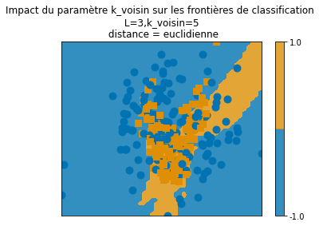

```python
X_train, y_train, X_test, y_test = build_dataset(X_3_data_rand_clown, Y_3_data_rand_clown)

knn_clf = KNeighborsClassifier(n_neighbors=5, metric = 'euclidean')
knn_clf = knn_clf.fit(X_train, y_train)
frontiere_new2(knn_clf, X_3_data_rand_clown, Y_3_data_rand_clown, n_neighbors=5)
```

#### Dataset 4# : Rand_Checker

```
            0         1
1   -0.147988  0.420961
3    0.024767 -0.222096
5    0.249618 -1.407714
7    1.625416 -0.696424
9   -0.978330 -1.138616
..        ...       ...
279 -0.694305  1.358287
281 -1.586373  0.166189
283 -1.046788 -1.110900
285  1.234305  1.978365
287 -0.562829  0.651055

[144 rows x 2 columns]
1      3.0
3      3.0
5      1.0
7      1.0
9      1.0
      ...
279    1.0
281    1.0
283    1.0
285    1.0
287    3.0
Length: 144, dtype: float64


-------------- X_train --------------


[[-0.45711841  0.06807823]
 [-0.37981485 -1.04838304]
 [ 1.73619986  1.10587958]
 [ 0.42318062  0.88865793]
 [-0.36248519  0.74611614]
 [ 0.01065096 -1.2805522 ]
 [-0.62943437 -1.4893339 ]
 [ 1.32845557  0.29122003]
 [ 0.85228051 -0.85542019]
```

[output cut: 304 more lines]

```


1      3.0
3      3.0
5      1.0
7      1.0
9      1.0
      ...
279    1.0
281    1.0
283    1.0
285    1.0
287    3.0
Length: 144, dtype: float64
(2550, 2)
```

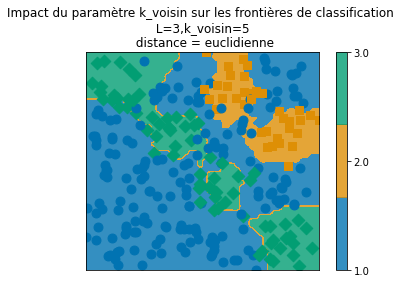

```python
X_train, y_train, X_test, y_test = build_dataset(X_4_data_rand_checker, Y_4_data_rand_checker)

knn_clf = KNeighborsClassifier(n_neighbors=5, metric = 'euclidean')
knn_clf = knn_clf.fit(X_train, y_train)
frontiere_new2(knn_clf, X_4_data_rand_checker, Y_4_data_rand_checker, n_neighbors=5)
```

#### Question 6

Pour les observations d’indice pair du jeu de données #2, faites varier le nombre k de voisins pris en compte : $k = 1,2,..., n$. Que devient la méthode dans le cas extrême où $k = 1$ ? $k = n$ ? Afficher ces cas sur les données étudiées en utilisant la fonction frontiere_new et présentez les dans une forme facilement lisible. Dans quels cas la frontière est-elle complexe ? simple ?

#### On fait varier le nombre de k-voisins proches sur le dataset #2 (Rand_tri_gauss)

```python
X_train, y_train, X_test, y_test = build_dataset(X_2_data_rand_tri_gauss, Y_2_data_rand_tri_gauss)
```

```
            0         1
1    0.605903 -0.794399
3   -1.170487 -0.961866
5   -1.767264 -1.834802
7   -1.079382 -1.359980
9   -1.441217 -2.783010
..        ...       ...
141  0.375014 -1.686443
143  1.984687 -0.774106
145  1.637102  0.795103
147  1.464358 -0.120975
149  1.509489  2.140515

[75 rows x 2 columns]
1      3.0
3      2.0
5      2.0
7      2.0
9      2.0
      ...
141    3.0
143    3.0
145    1.0
147    1.0
149    1.0
Length: 75, dtype: float64


-------------- X_train --------------


[[ 0.50642843  0.3244072 ]
 [ 0.59011295  0.64053854]
 [-1.24272853 -1.24500322]
 [-2.02393672  0.17612205]
 [-0.75742286  0.1112662 ]
 [ 0.17034616 -0.73253169]
 [-0.68454312  0.6588787 ]
 [-0.71533871  0.16676245]
 [ 1.0831879   0.45393914]
```

[output cut: 165 more lines]

```
-------------- y_test --------------


1      3.0
3      2.0
5      2.0
7      2.0
9      2.0
      ...
141    3.0
143    3.0
145    1.0
147    1.0
149    1.0
Length: 75, dtype: float64
```

#### Cas Extrême lorsque :

- $k-voisin = 1$
- $k-voisin = n$

#### k-voisin = 1

```
(2500, 2)
```

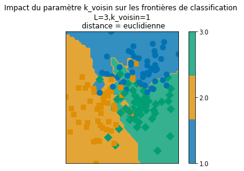

```python
# Pour k_voisin = 1

clf = KNeighborsClassifier(n_neighbors=1, metric = 'euclidean')
clf = clf.fit(X_train, y_train)
frontiere_new2(clf, X_2_data_rand_tri_gauss, Y_2_data_rand_tri_gauss, n_neighbors = 1, distance = "euclidienne")
```

```
(2500, 2)
```

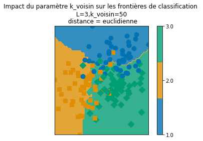

```python
# Pour k_voisin = n

clf = KNeighborsClassifier(n_neighbors = 50, metric = 'euclidean')
clf = clf.fit(X_train, y_train)
frontiere_new2(clf, X_2_data_rand_tri_gauss, Y_2_data_rand_tri_gauss, n_neighbors = 50, distance = "euclidienne")
```

```
(2500, 2)
```

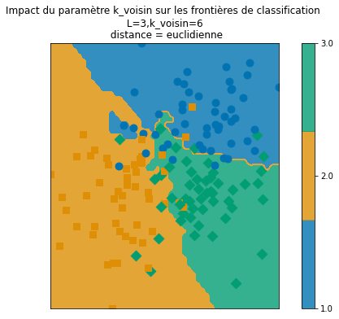

```
(2500, 2)
```

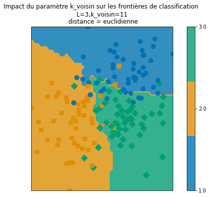

```
(2500, 2)
```

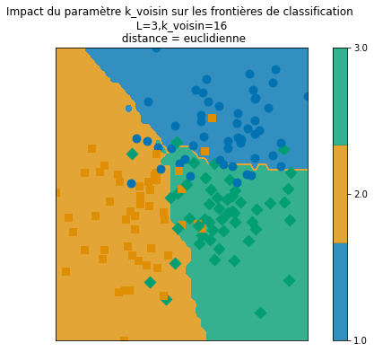

```
(2500, 2)
```

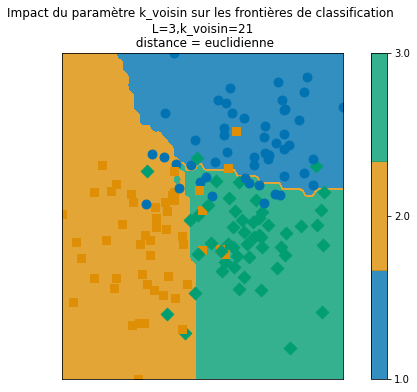

```
(2500, 2)
```

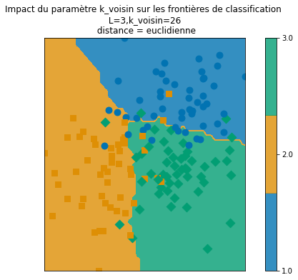

```
(2500, 2)
```

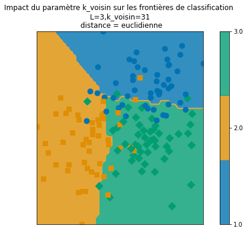

```
(2500, 2)
```

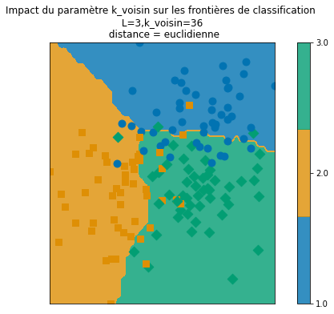

```python
# On crée un liste qui correspond au nombre de k_voisin
k_voisin = np.arange(1,45,5)

for i in range(1,8,1):
    plt.rcParams["figure.figsize"] = (10, 6)
    clf = KNeighborsClassifier(n_neighbors=k_voisin[i], metric = 'euclidean')
    clf = clf.fit(X_train, y_train)
    frontiere_new2(clf, X_2_data_rand_tri_gauss, Y_2_data_rand_tri_gauss, n_neighbors = k_voisin[i], distance = "euclidienne")
    plt.show()
```

#### Réponse :

Lorsque que l'on fait varier le paramètre **k_voisin**, nous remarquons que pour le cas **k_voisin = 1**, la frontière est complexe à tracer. En effet, l'algorithme KNN semble être particulièrement sensible au bruit qui se trouve dans les données. On peut en déduire que dans ce cas l'algorithme "sur-apprend".

A l'inverse lorsque le paramètre **k_voisin** devient grand (cas où **k_voisin = n** pour n suffisament grand), nous observons que la frontière est beaucoup moins complexe. En fait pour le cas **k_voisin = n** la classe la plus présente au sein des labels est prédite pour chaque point de données. Cela explique pourquoi lorsque **k_voisin = n**, la frontière disparait.

#### Question 7 :

Une variante possible très utilisée consiste à pondérer les poids du jème voisin selon $e^{-d_{j}^{2} / h}$ ($h$ contrôlant le niveau de pondération) : cela revient à remplacer l’Équation (2) par :

$\hat{f}_{k}(\mathrm{x}) \in \underset{y \in \mathcal{Y}}{\arg \max }\left(\sum_{j=1}^{k} \exp \left(-d_{j}^{2} / h\right) \mathbb{1}_{\left\{y_{r_{j}}=y\right\}}\right)$

##### Explication du paramètre "weights" de l'algorithme KNN de scikit-learn

- weights{‘uniform’, ‘distance’} or callable, default=’uniform’. Weight function used in prediction. Possible values:
- ‘uniform’ : uniform weights. All points in each neighborhood are weighted equally.
- ‘distance’ : weight points by the inverse of their distance. in this case, closer neighbors of a query point will have a greater influence than neighbors which are further away.

[callable] : a user-defined function which accepts an array of distances, and returns an array of the same shape containing the weights.

https://scikit-learn.org/stable/modules/generated/sklearn.neighbors.KNeighborsClassifier.html

#### Cas pour $h = 10^{(-2)}$

```
(2500, 2)
```

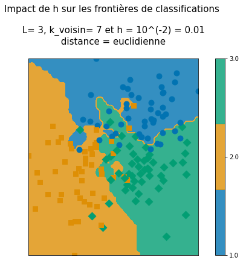

```python
def poids1(distance):
    h = ( 10 ** (-2) ) # h = 0.01
    return np.exp( (-distance ** 2) / h )

k = 7 # correspond au paramètre k_voisin

poid_knn = KNeighborsClassifier(n_neighbors=k, weights=poids1)
poid_knn.fit(X_train, y_train)
frontiere_new2(poid_knn, X_2_data_rand_tri_gauss, Y_2_data_rand_tri_gauss, n_neighbors = k, distance = "euclidienne")
plt.title("Impact de h sur les frontières de classifications \n\n L= 3, k_voisin= 7 et h = 10^(-2) = 0.01 \n distance = euclidienne \n", size = 15)
plt.show()
```

#### Cas pour $h = 10^{(-1)}$

```
(2500, 2)
```

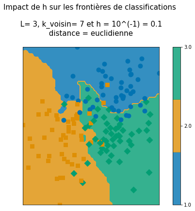

```python
def poids2(distance):
    h = ( 10 ** (-1) ) # h = 0.1
    return np.exp( (-distance ** 2) / h )

k = 7 # correspond au paramètre k_voisin

poid_knn = KNeighborsClassifier(n_neighbors=k, weights=poids2)
poid_knn.fit(X_train, y_train)
frontiere_new2(poid_knn, X_2_data_rand_tri_gauss, Y_2_data_rand_tri_gauss, n_neighbors = k, distance = "euclidienne")
plt.title("Impact de h sur les frontières de classifications \n\n L= 3, k_voisin= 7 et h = 10^(-1) = 0.1 \n distance = euclidienne \n", size = 15)
plt.show()
```

#### Cas pour $h = 10^{(0)}$

```
(2500, 2)
```

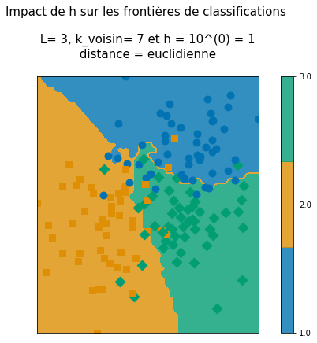

```python
def poids3(distance):
    h = ( 10 ** (0) ) # h = 1
    return np.exp( (-distance ** 2) / h )

k = 7 # correspond au paramètre k_voisin

poid_knn = KNeighborsClassifier(n_neighbors=k, weights=poids3)
poid_knn.fit(X_train, y_train)
frontiere_new2(poid_knn, X_2_data_rand_tri_gauss, Y_2_data_rand_tri_gauss, n_neighbors = k, distance = "euclidienne")
plt.title("Impact de h sur les frontières de classifications \n\n L= 3, k_voisin= 7 et h = 10^(0) = 1 \n distance = euclidienne \n", size = 15)
plt.show()
```

#### Cas pour $h = 10^{(1)}$

```
(2500, 2)
```

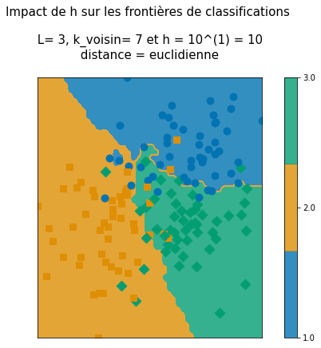

```python
def poids4(distance):
    h = ( 10 ** (1) ) # h = 10
    return np.exp( (-distance ** 2) / h )

k = 7 # correspond au paramètre k_voisin

poid_knn = KNeighborsClassifier(n_neighbors=k, weights=poids4)
poid_knn.fit(X_train, y_train)
frontiere_new2(poid_knn, X_2_data_rand_tri_gauss, Y_2_data_rand_tri_gauss, n_neighbors = k, distance = "euclidienne")
plt.title("Impact de h sur les frontières de classifications \n\n L= 3, k_voisin= 7 et h = 10^(1) = 10 \n distance = euclidienne \n", size = 15)
plt.show()
```

#### Cas pour $h = 10^{(2)}$

```
(2500, 2)
```

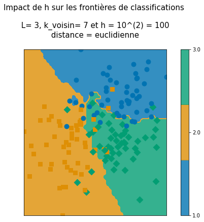

```python
def poids5(distance):
    h = ( 10 ** (2) ) # h = 100
    return np.exp( (-distance ** 2) / h )

k = 7 # correspond au paramètre k_voisin

poid_knn = KNeighborsClassifier(n_neighbors=k, weights=poids5)
poid_knn.fit(X_train, y_train)
frontiere_new2(poid_knn, X_2_data_rand_tri_gauss, Y_2_data_rand_tri_gauss, n_neighbors = k, distance = "euclidienne")
plt.title("Impact de h sur les frontières de classifications \n\n L= 3, k_voisin= 7 et h = 10^(2) = 100 \n distance = euclidienne \n", size = 15)
plt.show()
```

#### Question 8 :

Quel est le taux d’erreur sur les mêmes données d’apprentissage (i.e., la proportion d’erreur faite par le classifieur) lorsque k = 1 ? et sur des données de test (les observations d’indice pair) ?

```python
X_train, y_train, X_test, y_test = build_dataset(X_2_data_rand_tri_gauss, Y_2_data_rand_tri_gauss)
```

```
            0         1
1    0.605903 -0.794399
3   -1.170487 -0.961866
5   -1.767264 -1.834802
7   -1.079382 -1.359980
9   -1.441217 -2.783010
..        ...       ...
141  0.375014 -1.686443
143  1.984687 -0.774106
145  1.637102  0.795103
147  1.464358 -0.120975
149  1.509489  2.140515

[75 rows x 2 columns]
1      3.0
3      2.0
5      2.0
7      2.0
9      2.0
      ...
141    3.0
143    3.0
145    1.0
147    1.0
149    1.0
Length: 75, dtype: float64


-------------- X_train --------------


[[ 0.50642843  0.3244072 ]
 [ 0.59011295  0.64053854]
 [-1.24272853 -1.24500322]
 [-2.02393672  0.17612205]
 [-0.75742286  0.1112662 ]
 [ 0.17034616 -0.73253169]
 [-0.68454312  0.6588787 ]
 [-0.71533871  0.16676245]
 [ 1.0831879   0.45393914]
```

[output cut: 165 more lines]

```
-------------- y_test --------------


1      3.0
3      2.0
5      2.0
7      2.0
9      2.0
      ...
141    3.0
143    3.0
145    1.0
147    1.0
149    1.0
Length: 75, dtype: float64
```

```python
model_knn = KNeighborsClassifier(n_neighbors=1, metric = 'euclidean')
model_knn.fit(X_train,y_train)
predicted = model_knn.predict(X_test)

print("--------- Classes prédites par l'algorithme KNN de Scikit-Learn --------- \n")
print(predicted)

print("\n\n")

print("--------- y_test (classe réelle) --------- \n")
print(y_test.tolist())

# print(len(predicted))
# print(len(y_test))
```

```
--------- Classes prédites par l'algorithme KNN de Scikit-Learn ---------

[3. 2. 2. 2. 2. 3. 2. 2. 3. 1. 1. 1. 3. 2. 2. 3. 2. 1. 2. 2. 1. 3. 2. 2.
 3. 3. 2. 1. 1. 2. 3. 1. 3. 2. 1. 2. 1. 2. 2. 2. 1. 1. 3. 1. 2. 3. 1. 2.
 3. 1. 2. 2. 3. 3. 3. 1. 1. 1. 2. 3. 3. 1. 3. 3. 2. 3. 1. 2. 2. 3. 2. 3.
 1. 1. 1.]



--------- y_test (classe réelle) ---------

[3.0, 2.0, 2.0, 2.0, 2.0, 3.0, 2.0, 2.0, 3.0, 1.0, 1.0, 2.0, 3.0, 3.0, 2.0, 3.0, 2.0, 1.0, 3.0, 2.0, 3.0, 3.0, 2.0, 2.0, 3.0, 3.0, 3.0, 3.0, 2.0, 2.0, 1.0, 1.0, 3.0, 1.0, 1.0, 2.0, 1.0, 2.0, 3.0, 3.0, 1.0, 1.0, 3.0, 2.0, 2.0, 1.0, 1.0, 2.0, 3.0, 1.0, 2.0, 2.0, 1.0, 3.0, 1.0, 2.0, 1.0, 1.0, 2.0, 3.0,…
```

```python
score_knn_scikit_learn_ = score(predicted, y_test) # on appelle la fonction que l'on a défini au début de ce notebook
print("Pour k_voisin = 1 \nLe score sur le dataset de test est de " + str(round(score_knn_scikit_learn_, 2)) + " %")

score_knn_scikit_learn_bis = model_knn.score(X_train, y_train)
print("Pour k_voisin = 1 \nLe score sur le dataset d'entrainement est de " + str(round(score_knn_scikit_learn_bis, 2)*100) + " %")
```

```
Pour k_voisin = 1
Le score sur le dataset de test est de 70.67 %
Pour k_voisin = 1
Le score sur le dataset d'entrainement est de 100.0 %
```

#### Réponse :

On remarque que le score est plus faible sur le jeu de test que sur le jeu d'entrainement.

#### Question 9 :

Pour le dataset **#4** (**rand_checker**), en utilisant les observations d’indice pair pour l’apprentissage et les observations d’indice impair pour le test, tracez le taux d’erreur en fonction de k pour k = 1; 2; : : : ; 50. Vous pourrez utiliser la classe fournie ErrorCurve

#### Importation de la classe *ErrorCurve*

```python
class ErrorCurve(object):
    def __init__(self, k_range=None, weights='uniform'):
        if k_range is None:
            k_range = list(range(1, 6))
        self.k_range = k_range
        self.weights = weights

    def fit_curve(self, X, y, Xtest, ytest):
        def error_func(k):
            knn = neighbors.KNeighborsClassifier(n_neighbors=k,
                                                 weights=self.weights)
            knn.fit(X, y)
            error = np.mean(knn.predict(Xtest) != ytest)
            return error

        errors = list(map(error_func, self.k_range))
        self.errors = np.array(errors)
        self.y = y

    def plot(self, marker='o', maketitle=True, **kwargs):
        plt.plot(self.k_range, self.errors, marker=marker, **kwargs)
        plt.xlabel("K")
        plt.ylabel("Test error")

        if maketitle:
            plt.title("number of training points : %d" % len(self.y))
```

#### On génère les donées du dataset #4 _Rand*checker*

- Indice pair pour les données d'apprentissage ($X_{train}, y_{train})$
- Indice imppair pour les données d'apprentissage ($X_{test}, y_{test})$

```python
X_train, y_train, X_test, y_test = build_dataset(X_4_data_rand_checker, Y_4_data_rand_checker)
```

```
            0         1
1   -0.147988  0.420961
3    0.024767 -0.222096
5    0.249618 -1.407714
7    1.625416 -0.696424
9   -0.978330 -1.138616
..        ...       ...
279 -0.694305  1.358287
281 -1.586373  0.166189
283 -1.046788 -1.110900
285  1.234305  1.978365
287 -0.562829  0.651055

[144 rows x 2 columns]
1      3.0
3      3.0
5      1.0
7      1.0
9      1.0
      ...
279    1.0
281    1.0
283    1.0
285    1.0
287    3.0
Length: 144, dtype: float64


-------------- X_train --------------


[[-0.45711841  0.06807823]
 [-0.37981485 -1.04838304]
 [ 1.73619986  1.10587958]
 [ 0.42318062  0.88865793]
 [-0.36248519  0.74611614]
 [ 0.01065096 -1.2805522 ]
 [-0.62943437 -1.4893339 ]
 [ 1.32845557  0.29122003]
 [ 0.85228051 -0.85542019]
```

[output cut: 303 more lines]

```
-------------- y_test --------------


1      3.0
3      3.0
5      1.0
7      1.0
9      1.0
      ...
279    1.0
281    1.0
283    1.0
285    1.0
287    3.0
Length: 144, dtype: float64
```

#### On trace la courbe d'erreur pour le dataset #4 (Rand_checker)

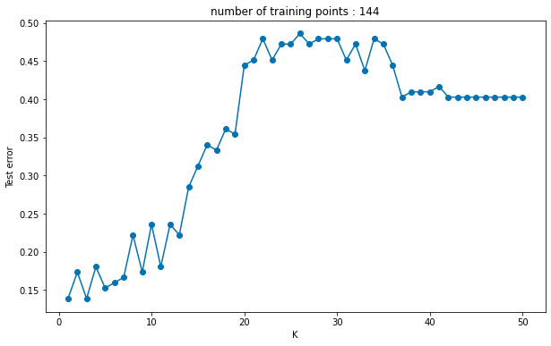

```python
# On défini une liste du nombre de k_voisin entre 1 et 50 pour un pas de 1
k_range_list = list(range(1, 51, 1))
courbe_erreur = ErrorCurve(k_range = k_range_list)
courbe_erreur.fit_curve(X_train, y_train, X_test, y_test)
courbe_erreur.plot()
```

#### Question 10 :

Tracez les différentes courbes d’erreur en fonction du paramètre k = (1; 2; : : : ; 50) sur le jeu de données #4, pour des nombres d’échantillons d’entrainement n prenant les valeurs 100, 200, 500 à 1000. Cette fois, tirez l’ensemble d’apprentissage et l’ensemble de test indépendamment et de même taille. Quelle est la meilleure valeur de k ? Est-ce la même pour les différents datasets ? Vous pourrez utiliser la classe fournie ErrorCurve. Pour n = 1000 visualisez les données et la règle de décision sur le même graphique. (Vous pouvez utiliser la fonction frontiere_new.)

#### On trace les différentes courbes d'erreur en fonction du paramètre l = (1,2,...,50) sur le dataset #4 _Rand*Checker* pour un nombre d'échantillon n = {100, 200, 500, 1000)

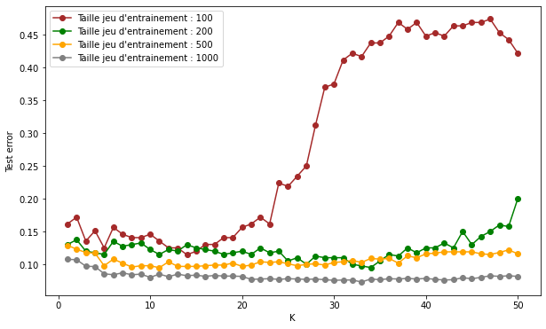

```python
n_value_echantillon = [100, 200, 500, 1000]
k_range_voisin = list(range(1, 51, 1))
counter = 0
for i in n_value_echantillon:

    n1 = i
    n2 = i

    # On génère le dataset d'apprentissage
    X_4_train, y4_train = source_TP2.rand_checkers(n1=n1, n2=n2, sigma=0.1)

    #  On génère le dataset de test
    X_4_test, y4_test = source_TP2.rand_checkers(n1=n1, n2=n2, sigma=0.1)

    courbe_erreur = ErrorCurve(k_range = k_range_voisin)
    courbe_erreur.fit_curve(X_4_train, y4_train, X_4_test, y4_test)
    #courbe_erreur.plot()
    courbe_erreur.plot(color=['brown', 'green', 'orange', 'grey'][counter], maketitle=False)
    counter = counter + 1
plt.legend(["Taille jeu d'entrainement : %d" % n for n in [100, 200, 500, 1000]], loc='upper left')
```

```
(2550, 2)
```

[figure not shown]

```python
# On génère le dataset d'apprentissage
n1 = 1000
n2 = 1000

X_4_train_1000, y4_train_1000 = source_TP2.rand_checkers(n1=n1, n2=n2, sigma=0.1)

#  On génère le dataset de test
X_4_test_1000, y4_test_1000 = source_TP2.rand_checkers(n1=n1, n2=n2, sigma=0.1)

model_knn_1000 = KNeighborsClassifier(n_neighbors=k)
model_knn_1000.fit(X_4_train_1000, y4_train_1000)
frontiere_new2(model_knn_1000, X_4_data_rand_checker, Y_4_data_rand_checker, n_neighbors = 10, distance = "euclidienne")
plt.title("Frontières de classifications \n\n Dataset = Rand_Checker, k_voisin= 10 et n_sample = 1000 \n distance = euclidienne \n", size = 15)
plt.show()
```

#### Réponse

Quel est le meilleur K ?

Le valeur optimale de K est celle qui minimise la fonction d'erreur

#### Question 11 :

A votre avis, quels sont les avantages et les inconvénients de la méthode des plus proches voisins : temps de calcul ? passage à l’échelle ? interprétabilité ?

#### Réponse :

L'algorithme KNN classifieur possède 2 paramètres importants qui sont :

- Le choix du nombre de k_voisin
- La méthode retenue pour le calcul des distances entre les points de données

L'avantage de l'algorithme KNN classifieurs est qu'il est simple à comprendre ce qui facilite ainsi l'interprétation des résultats. De plus, l'algorithme fournie des performances raisonnables sans avoir à effectuer de nombreux ajustements. Par ailleurs, KNN ne fait pas d'hypothèses sur les données d'entrée et il gère les valeurs aberrantes.

Cependant, même si il est simple d'employer un KNN classifieur, le temps de prédiction du temps augmentera en fonction de la taille des données. En effet, sur un dataset de grande taille, le temps d'execution de l'algorithme peut être long. Cela signifie que le nettoyage de données et la sélection des variables sont des étapes importantes à effectuer en amont. En effet, si le dataset comporte un nombre important de variables explicatives (feature) la précision des prédiction réalisées l'algorithme KNN chutera. Par ailleurs, généralement, les performances de ce dernier sera mauvaise si le dataset comporte des caratéristiques nulles (sparse dataset). De plus le choix optimal du paramètre k_voisin n'est pas toujours évident à trouver.

En conclusion, l'algorithme KNN classifieur est simple à comprendre, mais il n'est pas souvent utilisé en pratique à cause de sa lenteur sur des datasets volumineux mais aussi de son incapacité à gérer de nombreuses caractéristiques.

#### Question 12

Étudiez la base digits de scikit-learn. On pourra se référer à https://scikit-learn.org/stable/ auto_examples/classification/plot_digits_classification.html pour le chargement et la manipulation de la base de données. Décrivez la nature et le format des données (précisément), affichez un exemple. Tracez l’histogramme pour des classes. Coupez l’échantillon en deux parties de même taille et utilisez la première partie pour l’apprentissage et la deuxième pour le test. Appliquez la méthode aux données issues de la base digits pour un choix de $k \geq 1$ (e.g., k = 30) et indiquez le taux d’erreur.

#### On charge le dataset digits et on visualise le dataset

```python
data_digits = load_digits()
data_digits
```

[output not shown]

[output cut: 69 more lines]

```
         [ 0.,  0., 14., ..., 15.,  1.,  0.],
         [ 0.,  4., 16., ..., 16.,  7.,  0.],
         ...,
         [ 0.,  0.,  0., ..., 16.,  2.,  0.],
         [ 0.,  0.,  4., ..., 16.,  2.,  0.],
         [ 0.,  0.,  5., ..., 12.,  0.,  0.]],

        [[ 0.,  0., 10., ...,  1.,  0.,  0.],
         [ 0.,  2., 16., ...,  1.,  0.,  0.],
         [ 0.,  0., 15., ..., 15.,  0.,  0.],
         ...,
         [ 0.,  4., 16., ..., 16.,  6.,  0.],
         [ 0.,  8., 16., ..., 16.,  8.,  0.],
         [ 0.,  1.,  8., ..., 12.,  1.,  0.]]]),
 'DESCR': ".. _digits_dataset:\n\nOptical recognition of handwritten digits dataset\n--------------------------------------------------\n\n**Data Set Characteristics:**\n\n    :Number of Instances: 5620\n    :Number of Attributes: 64\n    :Attribute Information: 8x8 image of integer pixels in the ra…
```

```python
X_digits = data_digits.data
y_digits = data_digits.target

print("------------- X_digits -------------\n")
print(X_digits)
print("\nType de de X_digits : ", type(X_digits))
print("\nType des valeurs X_digits : ", X_digits.dtype)
print("\nDimensions de X_digits : " , X_digits.shape)
print("\nLa valeurs de X_digits: ")
print(" ", np.unique(X_digits))

print("\n")

print("------------- y_digits -------------\n")
print(y_digits)
print("\nType de de y_digits : ", type(y_digits))
print("\nType des valeurs y_digits : ", y_digits.dtype)
print("\nDimensions de y_digits : " , y_digits.shape)
print("\nLa valeurs de y_digits :")
print(" ", np.unique(y_digits))
```

```
------------- X_digits -------------

[[ 0.  0.  5. ...  0.  0.  0.]
 [ 0.  0.  0. ... 10.  0.  0.]
 [ 0.  0.  0. ... 16.  9.  0.]
 ...
 [ 0.  0.  1. ...  6.  0.  0.]
 [ 0.  0.  2. ... 12.  0.  0.]
 [ 0.  0. 10. ... 12.  1.  0.]]

Type de de X_digits :  <class 'numpy.ndarray'>

Type des valeurs X_digits :  float64

Dimensions de X_digits :  (1797, 64)

La valeurs de X_digits:
  [ 0.  1.  2.  3.  4.  5.  6.  7.  8.  9. 10. 11. 12. 13. 14. 15. 16.]


------------- y_digits -------------

[0 1 2 ... 8 9 8]

Type de de y_digits :  <class 'numpy.ndarray'>

Type des valeurs y_digits :  int32

Dimensions de y_digits :  (1797,)

La valeurs de y_digits :
  [0 1 2 3 4 5 6 7 8 9]
```

#### Traçons un histogramme pour visualiser la distribution des classes

On sait que les valeurs prisent par les sont : {0, 1, 2, 3, 4, 5, 6, 7, 8, 9}

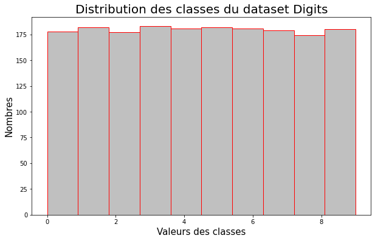

```python
x_hist = data_digits.target

plt.hist(x_hist, color = 'silver',
            edgecolor = 'red')
plt.xlabel('Valeurs des classes', size = 15)
plt.ylabel('Nombres', size = 15)
plt.title('Distribution des classes du dataset Digits', size = 20)
```

#### Visualisons les 5 premières images du dataset digits

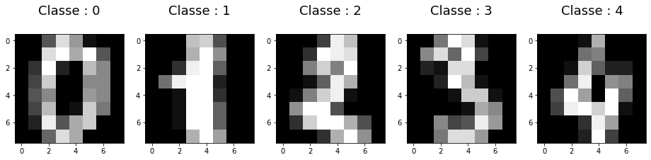

```python
plt.figure(figsize=(16,4))
for index in range(5):
    image = X_digits[index, :] # on sélectionne uniquement les 5 première lignes (i.e 5 premières images) de la matrice X_digits
    classe = y_digits[index] # on sélectionne les 5 premières classes du vecteur ligne y_digits
    plt.subplot(1, 5, index + 1)
    plt.imshow(np.reshape(image, (8,8)), cmap=plt.cm.gray)
    plt.title('Classe : %i\n' % classe, fontsize = 18)
plt.show()
```

#### On split de la dataset en 2 pour former notre dataset d'apprentissage et de test

```python
# Construction du dataset d'entrainement
print("------------- X_train_digits -------------\n")
X_train_digits = X_digits[: len(X_digits) // 2]
print(X_train_digits)
print("\n")
print("\nTaille de X_train_digits : ", len(X_train_digits))
print("\n")

print("\n------------- y_train_digits -------------\n")
y_train_digits = y_digits[: len(y_digits) // 2]
print(y_train_digits)
print("\n")
print("\nTaille de y_train_digits : ", len(y_train_digits))
print("\n")

# Construction du dataset de test
print("\n------------- X_test_digits -------------\n")
X_test_digits = X_digits[len(X_digits) // 2 :]
print(X_test_digits)
print("\n")
print("\nTaille de X_test_digits : ", len(X_test_digits))
print("\n")

print("\n------------- y_test_digits -------------\n")
y_test_digits = y_digits[len(y_digits) // 2 :]
print(y_test_digits)
print("\n")
print("\nTaille de y_train_digits : ", len(y_test_digits))

print("\n")

print("Taille y_train_digits + y_test_digits = ", len(y_train_digits) + len(y_test_digits))
print("Taille X_train_digits + X_test_digits = ", len(X_train_digits) + len(X_test_digits))
```

```
------------- X_train_digits -------------

[[ 0.  0.  5. ...  0.  0.  0.]
 [ 0.  0.  0. ... 10.  0.  0.]
 [ 0.  0.  0. ... 16.  9.  0.]
 ...
 [ 0.  0.  2. ... 14.  0.  0.]
 [ 0.  1. 12. ...  0.  0.  0.]
 [ 0.  0.  0. ...  3.  0.  0.]]



Taille de X_train_digits :  898



------------- y_train_digits -------------

[0 1 2 3 4 5 6 7 8 9 0 1 2 3 4 5 6 7 8 9 0 1 2 3 4 5 6 7 8 9 0 9 5 5 6 5 0
 9 8 9 8 4 1 7 7 3 5 1 0 0 2 2 7 8 2 0 1 2 6 3 3 7 3 3 4 6 6 6 4 9 1 5 0 9
 5 2 8 2 0 0 1 7 6 3 2 1 7 4 6 3 1 3 9 1 7 6 8 4 3 1 4 0 5 3 6 9 6 1 7 5 4
 4 7 2 8 2 2 5 7 9 5 4 8 8 4 9 0 8 9 8 0 1 2 3 4 5 6 7 8 9 0 1 2 3 4 5 6 7
 8 9 0 1 2 3 4 5 6 7 8 9 0 9 5 5 6 5 0 9 8 9 8 4 1 7 7 3 5 1 0 0 2 2 7 8 2
 0 1 2 6 3 3 7 3 3 4 6 6 6 4 9 1 5 0 9 5 2 8 2 0 0 1 7 6 3 2 1 7 3 1 3 9 1
 7 6 8 4 3 1 4 0 5 3 6 9 6 1 7 5 4 4 7 2 8 2 2 5 5 4 8 8 4 9 0 8 9 8 0 1 2
 3 4 5 6 7 8 9 0 1 2 3 4 5 6 7 8 9 0 1 2 3 4 5 6 7 8 9 0 9 5 5 6 5 0 9 8 9
 8 4 1 7 7 3 5 1 0 0 2 2 7 8 2 0 1 2 6 3 3 7 3 3 4 6 6 6 4 9 1 5 0 9 5 2 8
 2 0 0 1 7 6 3 2 1 7 4 6 3 1 3 9 1 7 6 8 4 3 1 4 0 5 3 6 9 6 1 7 5 4 4 7 2
 8 2 2 5 7 9 5 4 8 8 4 9 0 8 9 3 0 1 2 3 4 5 6 7 8 9 0 1 2 3 4 5 6 7 8 9 0
 1 2 3 4 5 6 7 8 9 0 9 5 5 6 5 0 9 8 9 8 4 1 7 7 3 5 1 0 0 2 2 7 8 2 0 1 2
 6 3 3 7 3 3 4 6 6 6 4 9 1 5 0 9 5 2 8 2 0 0 1 7 6 3 2 1 7 4 6 3 1 3 9 1 7
 6 8 4 3 1 4 0 5 3 6 9 6 1 7 5 4 4 7 2 8 2 2 5 7 9 5 4 8 8 4 9 0 8 9 8 0 1
 2 3 4 5 6 7 8 9 0 1 2 3 4 5 6 7 8 9 0 1 2 3 4 5 6 7 8 9 0 9 5 5 6 5 0 9 8
 9 8 4 1 7 7 3 5 1 0 0 2 2 7 8 2 0 1 2 6 3 3 7 3 3 4 6 6 6 4 9 1 5 0 9 5 2
 8 2 0 0 1 7 6 3 2 1 7 4 6 3 1 3 9 1 7 6 8 4 3 1 4 0 5 3 6 9 6 1 7 5 4 4 7
 2 8 2 2 5 7 9 5 4 8 8 4 9 0 8 9 8 0 1 2 3 4 5 6 7 8 9 0 1 2 3 4 5 6 7 8 9
 0 1 2 3 4 5 6 7 8 9 0 9 5 5 6 5 0 9 8 9 8 4 1 7 7 3 5 1 0 0 2 2 7 8 2 0 1
 2 6 3 3 7 3 3 4 6 6 6 4 9 1 5 0 9 5 2 8 2 0 0 1 7 6 3 2 1 7 4 6 3 1 3 9 1
 7 6 8 4 3 1 4 0 5 3 6 9 6 1 7 5 4 4 7 2 8 2 2 5 7 9 5 4 8 8 4 9 0 8 9 8 0
 1 2 3 4 5 6 7 8 9 0 1 2 3 4 5 6 7 8 9 0 1 2 3 4 5 6 7 8 9 0 9 5 5 6 5 0 9
```

[output cut: 46 more lines]

```
 1 2 3 4 5 6 7 8 9 0 9 5 5 6 5 0 9 8 9 8 4 1 7 7 3 5 1 0 0 2 2 7 8 2 0 1 2
 6 3 3 7 3 3 4 6 6 6 4 9 1 5 0 9 5 2 8 0 1 7 6 3 2 1 7 4 6 3 1 3 9 1 7 6 8
 4 3 1 4 0 5 3 6 9 6 1 7 5 4 4 7 2 2 5 7 9 5 4 4 9 0 8 9 8 0 1 2 3 4 5 6 7
 8 9 0 1 2 3 4 5 6 7 8 9 0 1 2 3 4 5 6 7 8 9 0 9 5 5 6 5 0 9 8 9 8 4 1 7 7
 3 5 1 0 0 2 2 7 8 2 0 1 2 6 3 3 7 3 3 4 6 6 6 4 9 1 5 0 9 5 2 8 2 0 0 1 7
 6 3 2 1 7 4 6 3 1 3 9 1 7 6 8 4 3 1 4 0 5 3 6 9 6 1 7 5 4 4 7 2 8 2 2 5 7
 9 5 4 8 8 4 9 0 8 9 8]



Taille de y_train_digits :  899


Taille y_train_digits + y_test_digits =  1797
Taille X_train_digits + X_test_digits =  1797
```

#### On applique l'algorithme KNN classifieur sur le dataset digits avec les paramètres suivants :

- k_voisin = 30
- Distance = euclidienne

```python
knn_digits = KNeighborsClassifier(n_neighbors=30, metric = 'euclidean')
knn_digits.fit(X_train_digits,y_train_digits)
predicted_digits = knn_digits.predict(X_test_digits)
print(predicted_digits)
```

```
[8 6 4 9 0 8 9 1 2 2 3 4 5 6 7 8 9 0 2 2 3 4 5 6 7 8 9 0 2 2 3 4 9 6 7 8 9
 0 9 5 5 6 5 0 9 8 9 8 4 3 7 7 3 9 1 2 7 8 2 0 1 2 6 3 3 7 3 9 4 6 6 6 4 9
 1 5 0 9 5 2 8 2 0 0 1 7 6 9 2 2 0 6 3 1 3 9 1 7 6 8 4 3 1 4 0 5 3 6 9 6 2
 7 5 4 4 7 2 8 2 2 9 7 9 5 4 4 9 0 8 9 8 0 1 2 3 4 5 6 7 8 3 0 1 2 3 4 5 6
 7 8 9 0 1 2 3 4 5 6 7 8 3 0 9 5 5 6 5 0 9 8 9 8 4 1 7 7 3 5 1 0 0 7 8 2 0
 1 2 6 3 3 7 3 3 4 6 6 6 4 9 1 5 0 8 5 2 3 3 0 0 1 7 6 3 2 1 7 4 6 3 1 7 9
 1 7 6 8 4 3 1 4 0 5 3 6 9 6 1 7 5 4 4 7 2 8 2 2 5 7 3 5 4 3 8 4 9 0 8 9 8
 0 1 2 3 4 5 6 7 3 9 0 1 2 3 4 5 6 7 8 9 0 1 2 3 4 5 6 7 8 9 0 9 5 5 6 5 0
 9 8 9 5 4 1 7 7 5 6 1 0 0 2 2 7 5 2 0 1 2 6 3 3 7 3 3 4 6 6 6 4 9 1 5 0 9
 5 2 5 2 0 0 1 7 6 3 2 1 7 4 6 3 1 3 9 1 7 6 8 4 3 1 4 0 5 3 6 9 6 5 7 5 4
 4 7 2 2 2 2 5 7 9 5 4 1 8 4 9 0 8 9 8 0 1 2 3 4 5 6 7 8 9 0 1 2 3 0 5 6 7
 8 9 0 1 2 3 4 5 6 7 8 9 0 9 5 5 6 5 0 9 8 9 8 4 1 7 7 3 5 1 0 0 3 3 7 8 3
 0 1 2 6 3 3 7 3 3 4 6 6 6 4 9 1 5 0 9 6 2 8 3 0 0 1 7 6 3 2 1 7 4 6 3 1 3
 9 1 7 6 8 4 3 1 4 0 5 3 6 9 6 1 7 5 4 4 7 2 8 2 2 6 7 9 5 4 1 8 4 0 0 8 0
 1 2 3 4 5 6 7 8 9 0 1 2 3 4 5 6 7 8 9 0 1 2 3 4 5 6 7 8 9 0 9 5 5 6 5 0 9
 8 9 8 4 1 7 7 3 5 1 0 0 2 2 7 9 2 0 1 2 6 3 3 7 3 3 4 6 6 6 4 9 1 5 0 9 5
 2 3 2 0 0 9 7 6 3 2 1 7 4 6 3 1 3 9 1 7 6 8 4 3 9 4 0 5 3 6 9 6 1 7 5 4 4
 7 2 8 2 2 5 7 9 5 4 8 8 4 9 0 8 9 8 0 1 2 3 4 5 6 2 1 9 0 1 2 3 4 5 6 9 0
 1 2 3 4 5 6 7 5 9 4 9 5 5 6 5 0 9 8 5 8 4 1 7 7 3 5 1 0 0 0 2 7 8 2 0 1 2
 6 5 7 7 7 3 4 6 6 6 7 9 1 5 0 9 5 3 8 0 1 7 6 3 2 1 7 7 6 3 1 3 9 1 7 6 8
 4 3 1 4 0 5 3 6 9 6 1 7 5 4 4 7 2 2 5 7 3 5 8 4 5 0 8 9 7 0 1 2 3 4 5 6 7
 3 9 0 1 2 3 4 5 6 7 8 9 0 1 2 3 4 5 6 7 8 9 0 9 5 5 6 5 0 9 8 9 8 4 1 7 7
 7 5 1 0 0 2 2 7 8 2 0 1 2 6 3 8 7 3 3 4 6 6 6 4 9 1 5 0 9 5 2 8 2 0 0 1 7
 6 3 2 1 7 4 6 3 1 3 9 1 7 6 8 4 5 1 4 0 5 3 6 9 6 1 7 5 4 4 7 2 3 2 2 5 7
 9 5 4 1 1 4 9 0 8 9 8]
```

#### On calcure de taux d'erreur grâce à notre fonction *score()*

```python
score_knn_digits = score(predicted_digits, y_test_digits) # on appelle la fonction que l'on a défini au début de ce notebook
print("Pour k_voisin = 30 \nLe score est de " + str(round(score_knn_digits, 2)) + " %")
```

```
Pour k_voisin = 30
Le score est de 92.55 %
```

```python
from sklearn.metrics import confusion_matrix

conf_matrix = confusion_matrix(y_test_digits, predicted_digits)
print(conf_matrix)
```

```
[[87  0  0  0  1  0  0  0  0  0]
 [ 0 82  5  1  0  1  0  0  0  2]
 [ 1  0 79  6  0  0  0  0  0  0]
 [ 0  0  0 81  0  3  0  4  1  2]
 [ 2  0  0  0 87  0  0  2  1  0]
 [ 0  0  0  0  0 85  3  0  0  3]
 [ 0  0  0  0  0  0 91  0  0  0]
 [ 0  0  1  0  0  0  0 88  0  0]
 [ 0  6  1  6  0  4  1  1 68  1]
 [ 1  0  0  4  0  2  0  0  1 84]]
```

#### On visualise la matrice de confusion affichée ci-dessus

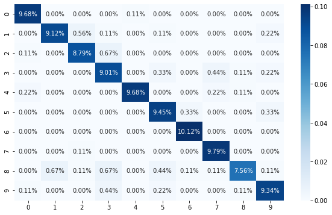

```python
import seaborn as sns

sns.heatmap(conf_matrix/np.sum(conf_matrix), annot=True,
            fmt='.2%', cmap='Blues')
```

#### Question 13 :

Proposez une méthode pour choisir k et mettez-la en oeuvre. Vous pourrez utiliser la classe fournie LOOCurve. En utilisant toutes les données, tracez la courbe du taux d’erreur leave-one-out pour k = 1; 6; 11; 16; 21; 26; 31; 36; 41; 46; 100; 200. Pour plus d’information sur la validation croisée (crossvalidation) on peut consulter [HTF09, Chapitre 7.10].

#### On importe la classe *LOOCurve*

```python
class LOOCurve(object):
    """Leave-One-Out (LOO) curve"""
    def __init__(self, k_range=None, weights='uniform'):
        if k_range is None:
            k_range = list(range(1, 6))
        self.k_range = k_range
        self.weights = weights

    def fit_curve(self, X, y, n_iter=200, random_state=1):
        def score_func(k):
            n_samples = len(X)
            # Selon la verson de scikit-learn : shuffleSplit prend en argument
            # 'niter ' ou niterations'. De plus, l'argument test_size peut ne
            # pas etre reconnu. Il est recommande de consulter
            # help(model_selection.ShuffleSplit) pour connaitre la liste
            # des arguments reconnus par votre version de sickitlearn.
            loo = model_selection.ShuffleSplit(n_iter,
                                                test_size=1,
                                                train_size=n_samples-1,
                                                random_state=random_state)
            knn = neighbors.KNeighborsClassifier(n_neighbors=k,
                                                 weights=self.weights)
            scores = model_selection.cross_val_score(estimator=knn,
                                                      X=X, y=y,
                                                      cv=loo)
            return np.mean(scores)

        scores = list(map(score_func, self.k_range))
        self.cv_scores = np.array(scores)
        self.y = y

    def plot(self, marker='o', maketitle=True, **kwargs):
        plt.plot(self.k_range, self.cv_scores, marker=marker, **kwargs)
        plt.xlabel("K")
        plt.ylabel("Leave One Out Score (1-error rate)")
        if maketitle:
            plt.title("number of training points : %d" % (len(self.y) - 1))
```

```python
# On crée la liste des valeurs de k_voisin = {1; 6; 11; 16; 21; 26; 31; 36; 41; 46; 100; 200}

# On initialise la liste qui contiendra les valeurs des k_voisin
k_voisin_list_ = list()

# On génère les valeurs compris en 1 et 46
k_voisin_list_ = np.arange(1, 50, 5)
k_voisin_list_ = k_voisin_list_.tolist()

k_voisin_list_.append(100)
k_voisin_list_.append(200)

k_voisin_list_
```

```
[1, 6, 11, 16, 21, 26, 31, 36, 41, 46, 100, 200]
```

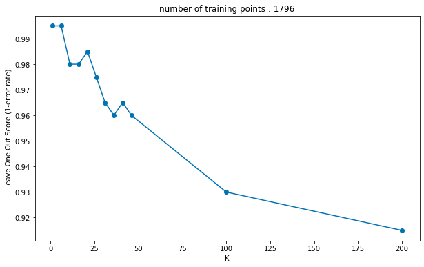

```python
loo_curve = LOOCurve(k_range = k_voisin_list_)
loo_curve.fit_curve(X = X_digits, y = y_digits)
loo_curve.plot()
```

### Réponse :

Afin d'évaluer les performande du modèle KNNClassifier, il est nécéssaire de regarder à quel point les prédictions faites par le modèle correspondent aux données observées.

Pour ce faire, pour évaluer notre modèle, nous avons employé la méthode de validation croisée, Leave-one-out.

### Analyse Discriminante Linéaire (LDA)

#### Question 15 :

En utilisant la formule de Bayes donner la formule des probabilités a posteriori : $P{Y = +1 | X = x}$, $P{Y = −1 | X = x}$, comme fonctions de $f+$, $f−$ et $π+$.

#### Question 16 :

#### Calcul de :

$\log \left(\frac{\mathbb{P}\{Y=+1 \mid X=\mathbf{x}\}}{\mathbb{P}\{Y=-1 \mid X=\mathbf{x}\}}\right)$ en fonction de $π^+$, $µ^+$, $µ^−$ et $Σ$.

#### Question 17 :

#### Donnons une justification au choix du classifieur

$\left\{\begin{aligned} 1 & \text { si } x^{\top} \widehat{\Sigma}^{-1}\left(\widehat{\mu}_{+}-\widehat{\mu}_{-}\right)>\frac{1}{2} \widehat{\mu}_{+}^{\top} \widehat{\Sigma}^{-1} \widehat{\mu}_{+}-\frac{1}{2} \widehat{\mu}_{-}^{\top} \widehat{\Sigma}^{-1} \widehat{\mu}_{-}+\log (1-m / n)-\log (m / n) \\ -1 & \text { sinon } \end{aligned}\right.$

#### Question 18 :

Écrivez votre propre classe LDAClassifier avec les méthodes d’apprentissage fit et de classification predict.

### Implémentation de LDAClassifier from scratch

```python
class LDAClassifier(BaseEstimator, ClassifierMixin):

    def fit(self, X, y):
        nb_ligne = X.shape[0]
        nb_colonne = X.shape[1]

        # On tri par ordre croissant les indices dont les valeurs de y sont les plus petites
        idx_sorted = y.argsort()

        # On trie X avec les indices y triées
        X_sorted = X[idx_sorted,:]

        # On trie les valeurs de y dans l'ordre croissant
        y_sorted = np.sort(y)

        # On compte l'occurence des classes de la variable cible y
        counter_label = np.unique(y, return_counts=True)

        # On stocke le nombre d'occurence du plus petit label
        counter_small_label = counter_label[1][0]

        # On génère un liste de valeurs allant de 0 à counter_small_label
        n1 = np.arange(0, counter_small_label, 1)
        n2 = np.arange(counter_small_label, nb_ligne)

        # On initialise mu_moins (i.e valeur de X trié entre 0 et counter_small_label)
        mu_moins = np.mean(X_sorted[n1,:], axis=0) # mu négatif

        # On initialise mu_plus (i.e valeur de X trié entre 12000 et la longueur de X trié)
        mu_plus = np.mean(X_sorted[n2,:], axis=0) # mu positif

        # On calcule la matrice de covariance (i.e cov(mu_moins, mu_plus))
        matrice_cov = (np.cov(X_sorted[n1,:].T) *
                       (counter_small_label - 1) + np.cov(X_sorted[n2,:].T) *
                       (nb_ligne - counter_small_label - 1)) / (nb_ligne - 2)

        # On calcule le membre de gauche de l'inégalité
        self.membre_gauche = np.dot( np.linalg.inv(matrice_cov), ( mu_plus - mu_moins ) )

        # On calcule le membre de droite de l'inégalité
        self.membre_droite = np.dot( np.dot( (1/2) * mu_plus.T, np.linalg.inv(matrice_cov)), mu_plus ) - np.dot( np.dot((1/2) * mu_moins.T, np.linalg.inv(matrice_cov)), mu_moins) + np.log(counter_small_label / nb_ligne) -  np.log(1. - (counter_small_label / nb_ligne) )

        return self

    def predict(self, X):
        taille_data = X.shape[0]
        n_var = X.shape[1]
        result = ( np.round ( np.dot( X, self.membre_gauche ) > self.membre_droite ) * 2 - 1).astype(int)

        return result
```

#### Question 19 :

Importez le module sklearn.discriminant_analysis qui contient en particulier la classe LinearDiscriminantAnalysis qui nous servira dans la suite. Vérifiez la validité des résultats obtenus avec votre méthode en les comparant à ceux de la classe LinearDiscriminantAnalysis de scikit-learn en utilisant un jeu de données simulé. Vous proposerez votre propre méthode de comparaison (l’échantillon d’apprentissage doit être petit et l’échantillon de validation doit être assez grand ; on considère par ailleurs que m est différent de $n - m$, i.e., les deux classes ne sont pas représentées par le même nombre d’échantillons observés). Indiquez les taux d’erreur de $LDAClassifier$ et de LinearDiscriminantAnalysis et le nombre de cas où les prédictions coïncident. En utilisant votre classe $LDAClassifier$, visualisez la règle de classification. (Vous pouvez utiliser la fonction $frontiereNew$.)

#### Consturction du dataset d'apprentissage $X_{train}, y_{train}$

```python
X5_data_rand_bi_gauss,y5_data_rand_bi_gauss = source_TP2.rand_bi_gauss(25, 45, [1,1], [-1,-1], [0.9, 0.9], [0.9, 0.9])
X5_train = X5_data_rand_bi_gauss
y5_train = y5_data_rand_bi_gauss
```

#### Consturction du dataset de test $X_{test}, y_{test}$

```python
X5_data_rand_bi_gauss,y5_data_rand_bi_gauss = source_TP2.rand_bi_gauss(350000, 30000, [1,1], [-1,-1], [0.9, 0.9], [0.9, 0.9])
X5_test = X5_data_rand_bi_gauss
y5_test = y5_data_rand_bi_gauss
```

#### On applique la version "from scratch" de l'algorithme LDAClassifier

```python
LDA_Scratch = LDAClassifier()
LDA_Scratch.fit(X5_train, y5_train)
LDA_Scratch_pred = LDA_Scratch.predict(X5_test)
print(LDA_Scratch_pred)
```

```
[ 1  1  1 ... -1 -1  1]
```

#### On visualise $y_{test}$

```python
print(y5_test)
```

```
[1. 1. 1. ... 1. 1. 1.]
```

#### On applique l'algorithme LDA avec la librairie sklearn

```python
from sklearn.discriminant_analysis import LinearDiscriminantAnalysis
lda_clf = LinearDiscriminantAnalysis()
lda_clf.fit(X5_train, y5_train)
classe_pred_lda = lda_clf.predict(X5_test)
print(classe_pred_lda)
```

```
[ 1.  1.  1. ... -1. -1.  1.]
```

```python
# # METHODE TROP LONGUE

# def compare_lda(y_pred_lda_scratch, y_pred_lda):
#     counter = 0
#     print(len(y_pred_lda_scratch))
#     for i in range(len(y_pred_lda_scratch)):
#         if y_pred_lda_scratch[i] == y_pred_lda.tolist()[i]:
#             counter = counter + 1
#             print(counter)
#     print(str(counter) + " classes identiques prédites sur " + str(len(y_pred_lda_scratch)))

# compare_lda(LDA_Scratch_pred, classe_pred_lda)
```

#### On compare l'algorithme LDAClassifier from scratch à l'arlgorithme LDAClassifier de la librairie scikit-learn

On compte le nombre de classes identiques prédites entre ces deux modèles

```python
def compare_lda_new(y_pred_lda_scratch, y_pred_lda):
    counter_classe = (y_pred_lda_scratch == y_pred_lda).sum()
    print(str(counter_classe) + " classes identiques prédites sur " + str(len(y_pred_lda_scratch)))

compare_lda_new(LDA_Scratch_pred, classe_pred_lda)
```

```
380000 classes identiques prédites sur 380000
```

#### On calcul le taux d'erreur de 2 modèles

```python
def score_lda(y_pred, y_test):
    taux_erreur = (y_pred != y_test).sum()
    return round((taux_erreur * 100) / len(y_test),2)

score_lda_scratch = score_lda(LDA_Scratch_pred, y5_test)
print("Le taux d'erreur obtenu par la version from scratch du modèle LDA fait maison est de : " + str(score_lda_scratch) + " %")
print("\n")
score_lda_scikit = score_lda(classe_pred_lda, y5_test)
print("Le taux d'erreur obtenu par la version from scratch du modèle LDA la librairie Scikit-Learn est de : " + str(score_lda_scikit) + " %")
```

```
Le taux d'erreur obtenu par la version from scratch du modèle LDA fait maison est de : 9.11 %


Le taux d'erreur obtenu par la version from scratch du modèle LDA la librairie Scikit-Learn est de : 9.11 %
```

```
(1600, 2)
```

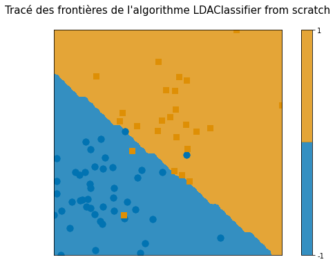

```python
source_TP2.plot_2d(X5_train, y5_train)
frontiere_new2(LDA_Scratch, X5_train, y5_train, w=None, step=40, alpha_choice=1)
plt.title("Tracé des frontières de l'algorithme LDAClassifier from scratch\n", size = 15)
```

#### Question 20 :

En utilisant votre classe LDAClassifier, visualisez la règle de classification pour les jeux de données #1 et #3. (Vous pouvez utiliser la fonction frontiere_new.) Discutez l’efficacité de la méthode dans ces deux cas.

On génère $X_{train}, y_{train}, X_{test}, y_{test}$ pour le data pour le dataset **#1 (Rand_bi_gauss)** et **#3 (Rand_clown)**

```python
X_1_data_rand_bi_gauss, Y_1_data_rand_bi_gauss = source_TP2.rand_bi_gauss(n1=20, n2=20, mu1=[1, 1], mu2=[-1, -1], sigmas1=[0.9, 0.9],
                  sigmas2=[0.9, 0.9])

X_3_data_rand_clown, Y_3_data_rand_clown = source_TP2.rand_clown(n1=150, n2=150, sigma1=1, sigma2=2)
```

#### Tracé des frontières pour le dataset #1 (Rand_bi_gauss) en utilisant l'algorithme LDAClissifier from scratch

```
(1600, 2)
```

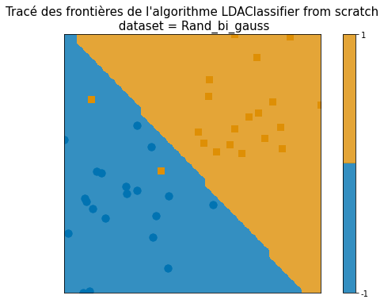

```python
LDA_Scratch_bi_gauss = LDAClassifier()
LDA_Scratch_bi_gauss.fit(X_1_data_rand_bi_gauss, Y_1_data_rand_bi_gauss)
source_TP2.plot_2d(X_1_data_rand_bi_gauss, Y_1_data_rand_bi_gauss)
frontiere_new2(LDA_Scratch_bi_gauss, X_1_data_rand_bi_gauss, Y_1_data_rand_bi_gauss, w=None, step=40, alpha_choice=1)
plt.title("Tracé des frontières de l'algorithme LDAClassifier from scratch\n dataset = Rand_bi_gauss", size = 15)
```

#### Tracé des frontières pour le dataset #3 (Rand_clown) en utilisant l'algorithme LDAClissifier from scratch

```
(1600, 2)
```

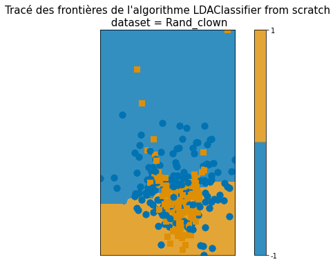

```python
LDA_Scratch_clown = LDAClassifier()
LDA_Scratch_clown.fit(X_3_data_rand_clown, Y_3_data_rand_clown)
source_TP2.plot_2d(X_3_data_rand_clown, Y_3_data_rand_clown)
frontiere_new2(LDA_Scratch_clown, X_3_data_rand_clown, Y_3_data_rand_clown, w=None, step=40, alpha_choice=1)
plt.title("Tracé des frontières de l'algorithme LDAClassifier from scratch\n dataset = Rand_clown", size = 15)
```

#### Réponse :

On discute de l'éfficacité de la méthode dans les 2 cas pour le dataset #1 et dataset #3 :